# Lego Homework - Rumi Allbert

```r
library(tidyverse)
library(dsbox)
```

## Exercises

### Exercise 1: What are the three most common first names of purchasers?

```r
name_count <- lego_sales %>%
     count(first_name)

sorted_name_count <- name_count %>%
     arrange(desc(n))

sorted_name_count[1:3,]
```

| first_name | n |
| --- | --- |
| Jackson | 13 |
| Jacob | 11 |
| Joseph | 11 |

#### In this sample, the most common first names among the purchasers are: Jackson (13), Jacob (11) and Jospeph (11).

### Exercise 2: What are the three most common themes of Lego sets purchased?

```r
theme_count <- lego_sales %>%
     count(theme)

sorted_theme_count <- theme_count %>%
     arrange(desc(n))

sorted_theme_count[1:3,]
```

| theme | n |
| --- | --- |
| Star Wars | 75 |
| Nexo Knights | 64 |
| Gear | 55 |

#### In this sample, the most common themes of lego among the purchasers are: Star Wars (75), Nexo Knights (64) and Gear (55).

### Exercise 3: Among the most common theme of Lego sets purchased, what is the most common subtheme?

```r
most_commom_subtheme <- lego_sales %>%
  filter(theme == "Star Wars") %>%
  count(subtheme, sort = TRUE)
most_commom_subtheme[1,]
```

| subtheme | n |
| --- | --- |
| The Force Awakens | 15 |

#### In this sample, the most common subtheme of the most common theme (Star Wars) is The Force Awakens (15).

### Exercise 4: Create a new variable called age_group and group the ages into the following categories: “18 and under”, “19 - 25”, “26 - 35”, “36 - 50”, “51 and over”

```r
lego_sales <- lego_sales %>%
  mutate(age_group = case_when(
    age <= 18 ~ "18 and under",
    age >= 19 & age <= 25 ~ "19 - 25",
    age >= 26 & age <= 35 ~ "26 - 35",
    age >= 36 & age <= 50 ~ "36 - 50",
    age >= 51 ~ "51 and over"))
```

#### For this exercise I create a new column in the lego sales dataframe which groups the different groups of ages, utilizing case_when().

### Exercise 5: Which age group has purchased the highest number of Lego sets?

```r
highest_n_legoset <- lego_sales %>%
    count(age_group, sort = TRUE)
highest_n_legoset[1,]
```

| age_group | n |
| --- | --- |
| 36 - 50 | 216 |

#### For this sample, it is the age group of 36 - 50 who have purchased the higest number of lego sets.

### Exercise 6: Which age group has spent the most money on Legos?

```r
highest_spender_agegroup <- lego_sales %>%
    count(us_price, sort = TRUE)
highest_spender_agegroup[1,]
```

| us_price | n |
| --- | --- |
| 9.99 | 108 |

### Exercise 7: Which Lego theme has made the most money for Lego?

```r
lego_sales <- lego_sales %>%
    mutate(theme_income = us_price * quantity)

highest_income_theme <- lego_sales %>%
    group_by(theme, theme_income) %>%
    count(theme, sort = TRUE) %>%
    arrange(desc(theme_income))

highest_income_theme[1,]
```

| theme | theme_income | n |
| --- | --- | --- |
| Ghostbusters | 699.98 | 1 |

```r
NA
```

### Exercise 8: Which area code has spent the most money on Legos? In the US the area code is the first 3 digits of a phone number.

```r
lego_sales <- lego_sales %>%
    mutate(theme_income = us_price * quantity)

lego_sales <- lego_sales %>%
    mutate(area_code = str_sub((phone_number), 1, 3))

highest_income_areacode <- lego_sales %>%
    group_by(area_code, theme_income) %>%
    count(area_code, sort = TRUE) %>%
    arrange(desc(theme_income))

highest_income_areacode[1,]
```

| area_code | theme_income | n |
| --- | --- | --- |
| 956 | 699.98 | 1 |

```r
NA
```

### Exercise 9: Why is Ghostbuster the lego theme that generated the most income? Is there a reason for this?

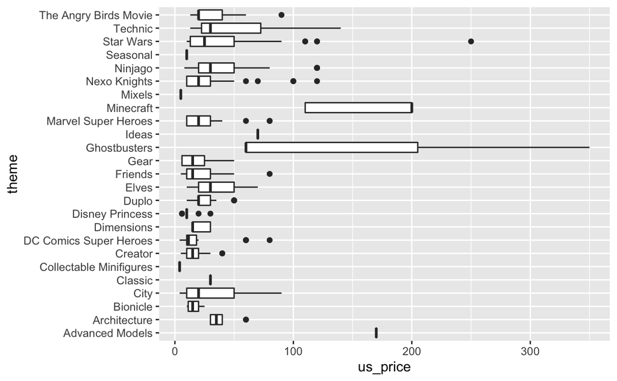

```r
ggplot(lego_sales, aes(us_price, theme)) + geom_boxplot()
```